# Running cn.mops on 20 teosinte from Palmar Chico

Simon Renny-Byfield

2015-02-02

This document records efforts to run the `R` package [`cn.mops`](http://www.bioconductor.org/packages/release/bioc/html/cn.mops.html) on 20 teosinte individuals from the Palmar Chico population, Mexico. As input to the program I have sorted `.bam` files (mapped by Vince Buffalo using [paap.py](https://github.com/vsbuffalo/paap)). These files symlinked in `/group/jrigrp4/cn.mops/data` from another location `/group/jrigrp4/teosinte-parents/aln/`.

Working in the `/group/jrigrp4/cn.mops/` directory I indexed the appropriate `.bam` files using the following scrip `scripts/index.bam.sh`:

```
#!/bin/bash -l
#!/bin/bash
#OUTDIR=/group/jrigrp4/cn.mops/output
#SBATCH -D /group/jrigrp4/cn.mops/output
#SBATCH -o /group/jrigrp4/cn.mops/logs/index_out_log-%j.txt
#SBATCH -e /group/jrigrp4/cn.mops/logs/index_err_log-%j.txt
#SBATCH -J index
#SBATCH --array=0-19
#SBATCH --mem-per-cpu=8000

##Simon Renny-Byfield, UC Davis, December 16 2014


echo "Starting Job:"
date

files=($(ls -d ../data/*sorted.bam))

#now index each .bam file

cmd="samtools index ${files[$SLURM_ARRAY_TASK_ID]}"
echo $cmd
eval $cmd

echo "End Job: "
date
```

Follwoing this I modified a script the Jinliang gave me. This script reads in the bam files, assess coverage and outputs `.bed` style output for CNVs and PAVs. The script is saved as `scripts/cnv_cnmpos.R`. At first I limited the analysis to the first 3 `.bam` files in the list. This is done by modifying the bam files list like this `BAMFiles[1:3]`.

```
# Simon Renny-Byfield
# 16/12/2014
# do a CNV call for 20 teosine lines from Palmar Chico
# modified from a script provided by Jinliang

#source("http://bioconductor.org/biocLite.R")
#biocLite("cn.mops")
len<-100
library(cn.mops)
BAMFiles <- list.files(path="/group/jrigrp4/cn.mops/data", pattern="sorted.bam$")
setwd("/group/jrigrp4/cn.mops/data")

chrs <- c("1", "2", "3", "4", "5", "6", "7", "8", "9", "10")
#for each chromosome
for (i in chrs ) {
        setwd("/group/jrigrp4/cn.mops/data")
        #try just chr 10 for now
        #chrs<-10
        #print(BAMFiles)
        bamDataRanges <- getReadCountsFromBAM(BAMFiles, refSeqName=i,  mode="paired",WL=len)

        #resHaplo <- haplocn.mops(bamDataRanges)
        #resCN <- calcIntegerCopyNumbers(resHaplo)
        # This function performs the cn.mops algorithm for copy number detection in NGS data
        res <- cn.mops(bamDataRanges)
        resCNV <- calcIntegerCopyNumbers(res)

        ### transform GRanges to data.frame
        mycnv <- cnvr(resCNV)


        cnvdf <- data.frame(chr=as.character(seqnames(mycnv)), start=start(mycnv), end=end(mycnv))
        callcnv <- mcols(mycnv)
        cnvdf <- cbind(cnvdf, callcnv)
        setwd("/group/jrigrp4/cn.mops/output")
        save(file=paste0("bamDataRanges_", i, ".RData"), list=c("bamDataRanges","cnvdf") )
}#for
```

Importantly this must be run from insde a slurm script. I used the following to get the job done:

```
#!/bin/bash
#OUTDIR=/group/jrigrp4/cn.mops/output
#SBATCH -D /group/jrigrp4/cn.mops/output
#SBATCH -o /group/jrigrp4/cn.mops/logs/cn.mops_out_log-%j.txt
#SBATCH -e /group/jrigrp4/cn.mops/logs/cn.mops_err_log-%j.txt
#SBATCH -J cn.mops
#SBATCH --mem=24000

export R_LIBS="~/R/x86_64-pc-linux-gnu-library/3.1"

echo "Starting cn.mops job: "
date

cmd="Rscript ../scripts/cnv_cnmpos.R"
echo $cmd
eval $cmd

echo "Job Ending: "
date
```

The data are now availalbe and have been moved to my desktop in `/Users/simonrenny-byfield/CNV_PAV`. Calls from each chromosome were combined into a single file called `cnv_calls.RData`.

## Testing CNV calls using Swanson-Wagner data and TIL01

Data from SW genome research [paper](http://genome.cshlp.org/content/20/12/1689.long#T3) is stored in `/Users/simonrenny-byfield/CNV_PAV/SW_data/SW_cnv_calls.csv`. The next step is to use this data to test our own CNV calls on TIL01. It is important to realize that some of the gene names have changed from RefV1 to RefV3.

Now we need the gene annotations to see which CNVs overlap with the genes. I can see two ways to do this:

1. Use the untrimmed data set, that is without regard to CNVs overlapping repeats.
2. USe the final trimmmed dataset which we will finally use in the SFS and selection analysis.

I think option 2 is probably the best so I will use the *final* set of CNVs.

Now I am just cheking iof the repeat region file is the correct one and I have the most uptodate version of the repeat gff. As it turns out AGPv3.22 is NOT the same as AGPv3.25. I have now sourced AGPv3.22 annotations and everything is on order and ready to go.

**(In)Congruence between SW ChiP and NGS data**

```
##                CNV CHiP normal CHiP
## CNV cn.mops         125         345
## normal cn.mops      705        1997
## total               830        2342
```

out of 147 overlaps (covering 125 genes) 108 cn.mops and sw calls are in the same direction (~73%)  
`TIL01` is a highly inbred line and as such shouold be homozygous, including for any PAVs/CNVs. Worryingly there are plenty of loci, actually even more in the outbred wild Palmar Chico population, that have odd copy numbers (i.e. 1,3, 5). After inbreeding CN should be 0,2,4,6 etc etc indicating homozygosity at each loci.

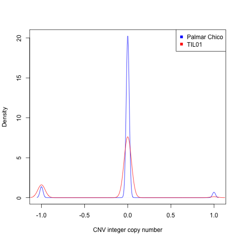

**An examination of false positive (FP) and true postive rates (TP)**

At the moment the FP and TP positive rates are not good. I have used the following script to gestimate the success of cn.mops runs.

```r
# A brief scrip to compare CNV calls from Swanson-Wagner,
# with CNVs called from the cn.mops algorithm.
# Simon Renny-Byfield, UC Davis, Jan 2015

# load in the R modules
library(dplyr)
library(GenomicRanges)
library(rtracklayer)

args <- commandArgs(trailingOnly = TRUE)

# set the wd
# setwd("/Users/simonrenny-byfield/CNV_PAV")
setwd(args[1])

####
# Load in the data
####

# firstly load in the gene and repeat data.
# gene.bed<-read.table("/Users/simonrenny-byfield/maize_genome/GeneZeaRefV3.bed")
# rep.bed<-read.table("/Users/simonrenny-byfield/maize_genome/RepeatZeaRefV3.bed")

# save(file="input_RData/beds.RData", list=c("rep.bed","gene.bed"))
# load("input_RData/beds.RData")
load("../input_RData/beds.RData")

# now load in the cnv calls
# load("input_RData/cnv_calls.RData")
load("cnv_calls.RData")

# now load in the SW CNV data
sw<-read.csv("../input_RData/SW_cnv_calls.csv")
swAll<-sw
# extract TIL01 and the gene names
sw<-sw[,c(1,4,34)]
#produce a list of genes with no evidence for CNVs in TIL01
swNeg<-subset(sw,sw$TIL1 == 0 )

####
# Extract the useful data
####

#modify the cn.mops data to look like the sw data
cnvdf<-sapply(cnvdf, function(x) as.numeric(gsub("CN","",x)))
# create a modify a temp df
tempdf<-cnvdf[,-c(1:3)]
tempdf[tempdf<2] <--1
tempdf[tempdf>2] <-1
tempdf[tempdf==2] <-0
# attribute this back to cnvdf
cnvdf[,-c(1:3)]<-tempdf

###
# Set up the some GRanges objects
###

# create a GRanges object from the data frame
cn.mopsRanges<-makeGRangesFromDataFrame(data.frame(cnvdf), keep.extra.columns = TRUE)
# create a Granges object from the repeat data
GRrep<-GRanges(seqnames=rep.bed$V1, ranges = IRanges(start=rep.bed$V2, end=rep.bed$V3))
# dito for the gene annotationns
GRgenes<-GRanges(seqnames=gene.bed$V1, ranges = IRanges(start=gene.bed$V2, end=gene.bed$V3, names = gene.bed$V4))

###
# now annnotate CNVs with genes they overlap
###

#find the CNV calls from cn.mops that iverlap gene annotations
CNgenes<-subsetByOverlaps(cn.mopsRanges,GRgenes,ignore.strand = TRUE, minoverlap=1, type="any")

# now find the SW gene names in GRgenes and extract those from the object
swAll<- swAll[!duplicated(swAll[,1]),]

#grab the Swanson-Wagner CNV genes from the GRgenes object, by name
SWgenes<-GRgenes[names(GRgenes) %in% swAll[,1] ]

# now grab the appropriate CNV calls from the swAll df
swTrim<-swAll[swAll[,1] %in% names(SWgenes),c(1,34)]

# add a metadata column of the sw CNV calls for TIL01
values(SWgenes)<-swTrim[,2]

######
# Calculate overlaps between CNgenes (i.e. genes with cn.mops calls)
# and SWgenes (i.e. genes that have Swanson-Wagner calls)
######

# now figure out the total overlap between cnv calls in TIL01 and all of the
# calls in sw, regardless of whether it is in TIL01 or not.
totalOverlap<-subsetByOverlaps(SWgenes,CNgenes,ignore.strand = TRUE, minoverlap=1, type="any")

# grab the sw genes with CNV calls in TIL01
swTIL<-SWgenes[SWgenes$value != 0]
# grab the cn.mops genes with calls in TIL01
cnTIL<-CNgenes[CNgenes$TIL01_sorted.bam !=0]

# now how many overlap with the cn.mops CNV calls?
TILvsTIL<-subsetByOverlaps(swTIL,cnTIL,ignore.strand = TRUE, minoverlap=1, type="any")
# so only 125/830 or ~15.1% recall between the chip and the cn.mops method.

# but do the calls agree???
idx.compare<-as.matrix(findOverlaps(swTIL,cnTIL,ignore.strand = TRUE, minoverlap=1, type="any"))
upDown.df<-cbind("sw"=swTIL$value[idx.compare[,1]],"cn.mops"=cnTIL$TIL01_sorted.bam[idx.compare[,2]])

length(upDown.df[,1][upDown.df[,1] == upDown.df[,2]])
#108/147 of the overlaps 73.5% of them agree in their call.

# now calculate the false positive rate, assuming that the sw is the gold standard
swNegTIL<-SWgenes[SWgenes$value == 0]

# break it down to up and down CNVs

# some important vairable
totalUp<-length(swTIL[swTIL$value == 1])
totalDown<-length(swTIL[swTIL$value == -1])
# access up sw CNVs
up.idx<-as.matrix(findOverlaps(swTIL[swTIL$value == 1],cnTIL,ignore.strand = TRUE, minoverlap=1, type="any"))
upCNVs.df<-cbind("sw"=swTIL$value[up.idx[,1]],"cn.mops"=cnTIL$TIL01_sorted.bam[up.idx[,2]])
agreeUp<-length(upCNVs.df[,1][upCNVs.df[,1] == upCNVs.df[,2]])

# of the 830 sw CNVs in TIL01 163 are up CNVs
# we correctly call 27 of these thus 27/163 = 16.56%

# access down sw CNVs
down.idx<-as.matrix(findOverlaps(swTIL[swTIL$value == -1],cnTIL,ignore.strand = TRUE, minoverlap=1, type="any"))
downCNVs.df<-cbind("sw"=swTIL$value[down.idx[,1]],"cn.mops"=cnTIL$TIL01_sorted.bam[down.idx[,2]])
agreeDown<-length(downCNVs.df[,1][downCNVs.df[,1] == downCNVs.df[,2]])

# of the 830 sw CNVs in TIL01 667 are down CNVs
# we correctly call 80 of these thus 80/667 = 12.0%


# calculate the overlap between negative calls in SWgenes
# and positive calls in cn.mops data
falsePositives<-subsetByOverlaps(swNegTIL,cnTIL,ignore.strand = TRUE, minoverlap=1, type="any")
# so a 345/2342 or ~14.7% of negative calls in sw have a call in cn.mops data.

# how many of these are down CNVs
falseDown<-subsetByOverlaps(swNegTIL,cnTIL[cnTIL$TIL01_sorted.bam == -1],ignore.strand = TRUE, minoverlap=1, type="any")
falseUp<-subsetByOverlaps(swNegTIL,cnTIL[cnTIL$TIL01_sorted.bam == 1],ignore.strand = TRUE, minoverlap=1, type="any")
###
# Make some tables to output some quality estimates
###

# a general summary of CNVs
allCalls<-data.frame("CNV Chip"=c(length(TILvsTIL),length(swTIL)-length(TILvsTIL),length(swTIL),(length(TILvsTIL)/length(swTIL))*100),"no CNV Chip"= c(length(falsePositives),length(swNegTIL)-length(falsePositives),length(swNegTIL),(length(falsePositives)/length(swNegTIL))*100))
rownames(allCalls)<-c("CNV cn.mops","no CNV cn.mops","total","%")
write.table(file="summary_allCalls.txt", allCalls)

# now for the overlapping CNV calls
direction.df<-data.frame("up"=c(agreeUp,totalUp-agreeUp,totalUp,(agreeUp/totalUp)*100),"down"=c(agreeDown,totalDown=agreeDown,totalDown,(agreeDown/totalDown)*100))
rownames(direction.df)<-c("CNV cn.mops","no CNV cn.mops","total","%")
write.table(file="summary_direction.txt", direction.df)

# now examine the false positives
falsePos.df<-data.frame("up CNVs" = c(length(falseUp), length(falseUp)+length(falseDown),
                          (length(falseUp)/(length(falseUp)+length(falseDown)))*100 ),
                              "down CNVs"=c(length(falseDown), length(falseUp)+length(falseDown),
                                    (length(falseDown)/(length(falseUp)+length(falseDown)))*100 ))

write.table(file="falsePos_direction.txt", falsePos.df)
```

I have tried a few runs using various parameters, currently `minWidth` in the `cn.mops()` function is modified from 1 to 5 and I have tried a new segmentation algorithm `"DNAcopy"` to see if that results in improvement. Jeff also suggested using the *NAM* lines from `HapMap2` to see if we can get better results with those samples.

**Alternatively use .bam files that have been filtered using MINMAPQ of 30**

The next step is to try using a strict filter on the teosinte Palmar Chico population read mapping data. So I filtered these files using samtools and the following command:

```
#!/bin/bash
#SBATCH -D /group/jrigrp4/cn.mops/data/filtered_bams
#SBATCH -o /group/jrigrp4/cn.mops/logs/out_log-%j.txt
#SBATCH -e /group/jrigrp4/cn.mops/logs/err_log-%j.txt
#SBATCH -J filter
#SBATCH  --cpus-per-task 4
#SBATCH --array=0-20


echo "Starting Job: "
date

cd ..
files=(*.bam)
cd filtered_bams/

file=${files[$SLURM_ARRAY_TASK_ID]}
cmd="samtools view -bhq 30 ../$file > filtered_$file"
echo $cmd
eval $cmd

echo "Ending Job: "
date
```